# Q2_md

Jonathan Burns

2022-08-26

## Research question and data summary

The second research question is investigating if retail employment differed from other industries. Several data transformations were generated to compare:

1. Industry groupings based on the IND1990 categories found here: https://cps.ipums.org/cps-action/variables/IND1990#codes_section
2. Filtering out Not In Universe and Military jobs to focus on the private sector
3. A binary variable that is TRUE when the industry is retail, and FALSE otherwise
4. Aggregated monthly employment rates by industry
5. Since the lock down began mid-March, all data from March 2020 is filtered out to prevent issues due to reporting inconsistencies

For reference, the average employment rates by industry are as follows:

```r
Q2_data_mo %>%
  group_by(Industry) %>%
  summarize("Employment Rate" = mean(Employment))
```

```
## # A tibble: 13 x 2
##    Industry                                                   `Employment Rate`
##    <fct>                                                                  <dbl>
##  1 AGRICULTURE, FORESTRY, AND FISHERIES                                   0.937
##  2 BUSINESS AND REPAIR SERVICES                                           0.931
##  3 CONSTRUCTION                                                           0.927
##  4 ENTERTAINMENT AND RECREATION SERVICES                                  0.833
##  5 FINANCE, INSURANCE, AND REAL ESTATE                                    0.964
##  6 MANUFACTURING                                                          0.942
##  7 MINING                                                                 0.907
##  8 PERSONAL SERVICES                                                      0.867
##  9 PROFESSIONAL AND RELATED SERVICES                                      0.949
## 10 PUBLIC ADMINISTRATION                                                  0.968
## 11 RETAIL TRADE                                                           0.901
## 12 TRANSPORTATION, COMMUNICATIONS, AND OTHER PUBLIC UTILITIES             0.932
## 13 WHOLESALE TRADE                                                        0.951
```

## Plots

A graph of each industry’s employment rate over time shows differences across industries:

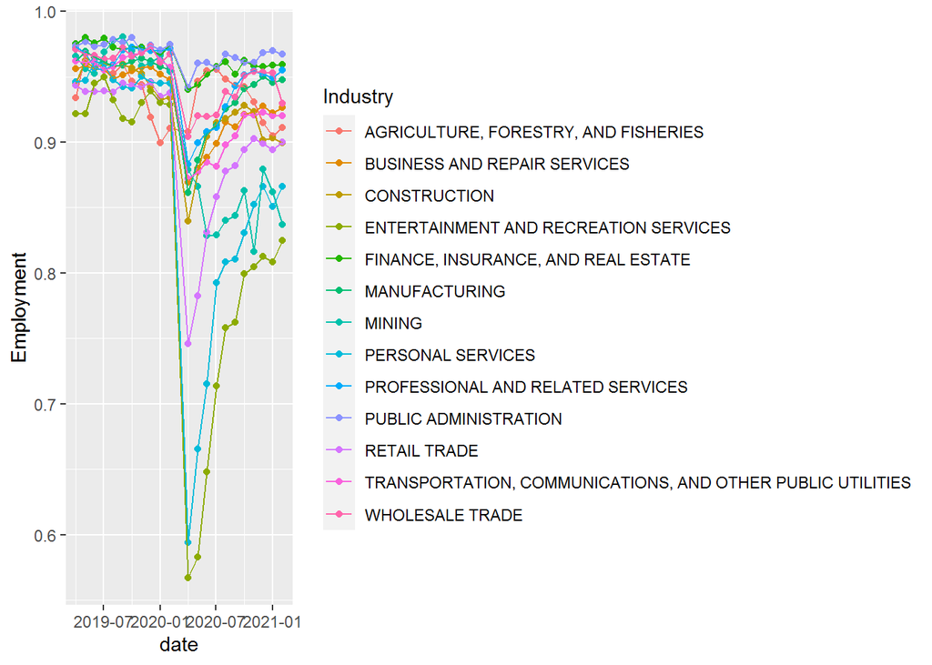

```r
ggplot(data = Q2_data_mo, aes(x=date, y=Employment, colour=Industry, group=Industry)) +
  geom_point() + geom_line()
```

While retail did not exhibit the strongest declines, it appears to have declined drastically more than the strongest and indeed was the third worst according to this graph.

Isolating Retail vs all other industries helps visualize this difference:

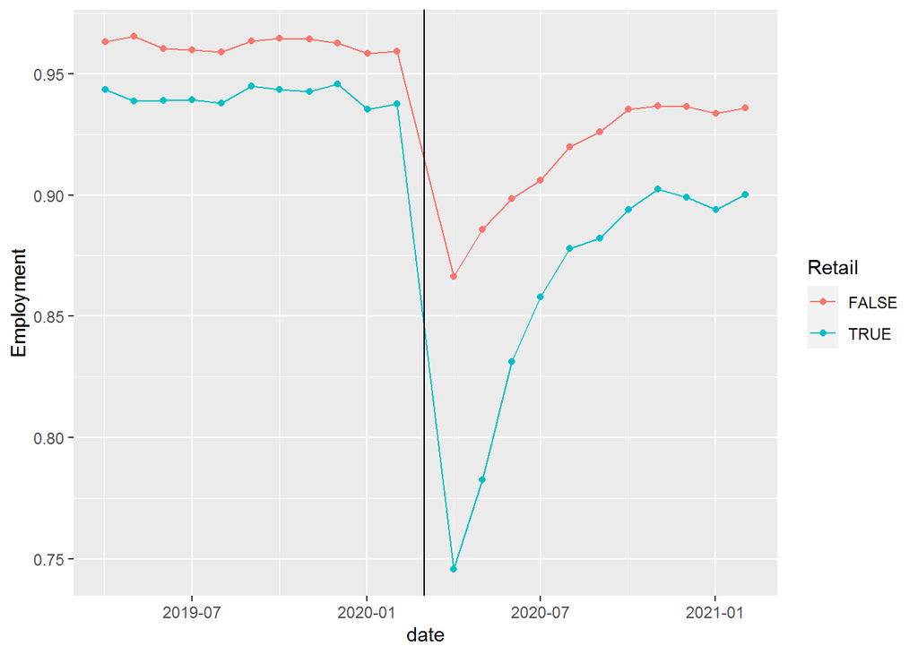

```r
ggplot(data=data_ret_summ, aes(x=date, y=Employment, colour=Retail)) +
  geom_point() +
  geom_line() +
  geom_vline(xintercept=ISOdate(2020,3,1))
```

While pre-pandemic employment is a bit lower for retail than other industries, the overall trend looks very similar. However, the decline immediately after lock downs was greater both absolutely and proportionately.

Next, rdplots were generated at first and second orders, for all industries and retail alone.

```
## [1] "Mass points detected in the running variable."
```

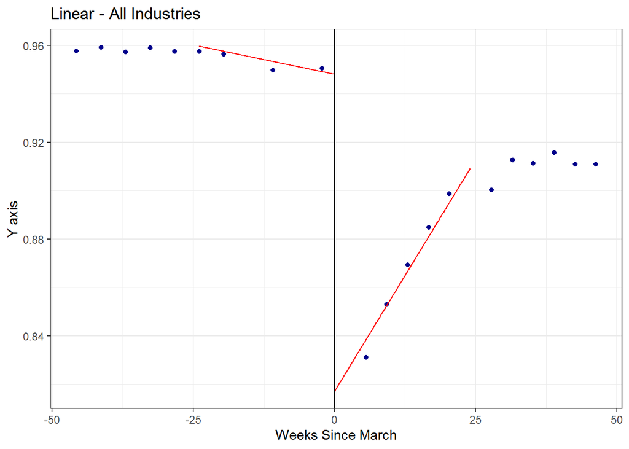

```r
rdplot(Q2_data_mo$Employment, Q2_data_mo$weeks, c=0, p=1, h=24, kernel = "uniform",
       title = "Linear - All Industries", x.label = "Weeks Since March")
```

```
## [1] "Mass points detected in the running variable."
```

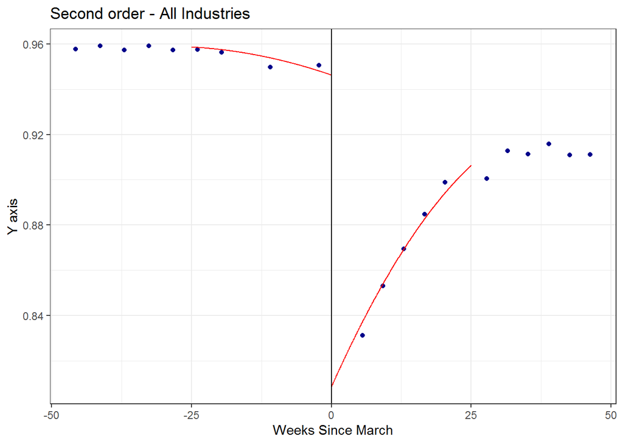

```r
rdplot(Q2_data_mo$Employment, Q2_data_mo$weeks, c=0, p=2, h=25, kernel = "uniform",
       title = "Second order - All Industries", x.label = "Weeks Since March")
```

```
## [1] "Mass points detected in the running variable."
```

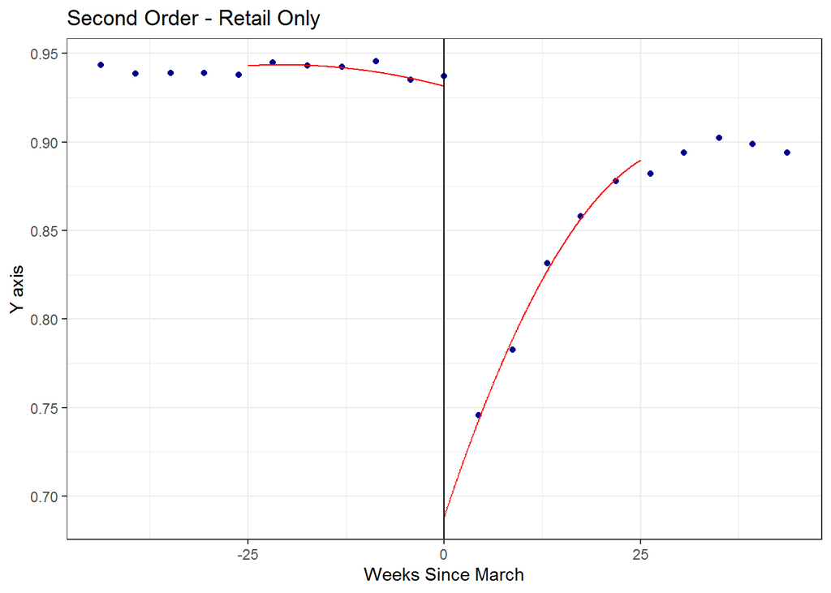

```r
rdplot(data_retail$Employment, data_retail$weeks, c=0, p=2, h=25, kernel = "uniform",
       title = "Second Order - Retail Only", x.label = "Weeks Since March")
```

## Models

Several models were created to analyze the pandemic, starting with a fixed effect ols model regressing employment by date and pre/post pandemic, with fixed effects applied by Industry:

```r
model_1 <- feols(Employment ~ weeks * disc_id | Industry, data=Q2_data_mo, vcov="hetero")
etable(model_1)
```

```
##                             model_1
## Dependent Var.:          Employment
##
## weeks              -0.0002 (0.0002)
## disc_id         -0.1072*** (0.0132)
## weeks x disc_id  0.0019*** (0.0004)
## Fixed-Effects:  -------------------
## Industry                        Yes
## _______________ ___________________
## S.E. type       Heteroskedast.-rob.
## Observations                    286
## R2                          0.66909
## Within R2                   0.50231
## ---
## Signif. codes: 0 '***' 0.001 '**' 0.01 '*' 0.05 '.' 0.1 ' ' 1
```

```r
wald(model_1)
```

```
## Wald test, H0: joint nullity of weeks, disc_id and weeks:disc_id
##  stat = 82.9, p-value < 2.2e-16, on 3 and 270 DoF, VCOV: Heteroskedasticity-robust.
```

The Wald test shows statistically significant coefficients by industry, but we can investigate further to provide more context via different methods.

Noting that weeks was not individually statistically significant to the model, four more models were generated using both rdrobust and feols to compare different structures:

```r
model_2 <- feols(Employment ~ weeks * disc_id | Retail, data=Q2_data_mo, se="hetero")
model_2_rd_r <- rdrobust(data_retail$Employment, data_retail$weeks, c=0, p=2, h=25, kernel = "uniform")
model_2_rd_nr <- rdrobust(data_non_retail$Employment, data_non_retail$weeks, c=0, p=2, h=25, kernel = "uniform")
model_3 <- feols(Employment ~ disc_id * Industry, data = Q2_data_mo, se="hetero")
```

Comparing the three feols() models:

```r
etable(model_1, model_2)
```

```
##                             model_1             model_2
## Dependent Var.:          Employment          Employment
##
## weeks              -0.0002 (0.0002)   -0.0002 (9.98e-5)
## disc_id         -0.1072*** (0.0132) -0.1072*** (0.0177)
## weeks x disc_id  0.0019*** (0.0004)  0.0019*** (0.0005)
## Fixed-Effects:  ------------------- -------------------
## Industry                        Yes                  No
## Retail                           No                 Yes
## _______________ ___________________ ___________________
## S.E. type       Heteroskedast.-rob. Heteroskedast.-rob.
## Observations                    286                 286
## R2                          0.66909             0.34474
## Within R2                   0.50231             0.33761
## ---
## Signif. codes: 0 '***' 0.001 '**' 0.01 '*' 0.05 '.' 0.1 ' ' 1
```

```r
etable(model_3)
```

```
##                                                                                     model_3
## Dependent Var.:                                                                  Employment
##
## (Intercept)                                                              0.9405*** (0.0067)
## disc_id                                                                    -0.0078 (0.0089)
## IndustryBUSINESSANDREPAIRSERVICES                                          0.0136* (0.0068)
## IndustryCONSTRUCTION                                                        0.0102 (0.0074)
## IndustryENTERTAINMENTANDRECREATIONSERVICES                                 -0.0103 (0.0074)
## IndustryFINANCE,INSURANCE,ANDREALESTATE                                  0.0331*** (0.0068)
## IndustryMANUFACTURING                                                     0.0210** (0.0068)
## IndustryMINING                                                            0.0240** (0.0072)
## IndustryPERSONALSERVICES                                                    0.0078 (0.0069)
## IndustryPROFESSIONALANDRELATEDSERVICES                                   0.0265*** (0.0070)
## IndustryPUBLICADMINISTRATION                                             0.0340*** (0.0067)
## IndustryRETAILTRADE                                                         0.0001 (0.0067)
## IndustryTRANSPORTATION,COMMUNICATIONS,ANDOTHERPUBLICUTILITIES             0.0220** (0.0068)
## IndustryWHOLESALETRADE                                                   0.0266*** (0.0068)
## disc_id x IndustryBUSINESSANDREPAIRSERVICES                             -0.0387*** (0.0109)
## disc_id x IndustryCONSTRUCTION                                           -0.0401** (0.0122)
## disc_id x IndustryENTERTAINMENTANDRECREATIONSERVICES                    -0.1875*** (0.0300)
## disc_id x IndustryFINANCE,INSURANCE,ANDREALESTATE                          -0.0110 (0.0092)
## disc_id x IndustryMANUFACTURING                                           -0.0307* (0.0124)
## disc_id x IndustryMINING                                                -0.1072*** (0.0114)
## disc_id x IndustryPERSONALSERVICES                                      -0.1539*** (0.0286)
## disc_id x IndustryPROFESSIONALANDRELATEDSERVICES                          -0.0289* (0.0120)
## disc_id x IndustryPUBLICADMINISTRATION                                     -0.0051 (0.0093)
## disc_id x IndustryRETAILTRADE                                           -0.0721*** (0.0183)
## disc_id x IndustryTRANSPORTATION,COMMUNICATIONS,ANDOTHERPUBLICUTILITIES -0.0527*** (0.0109)
## disc_id x IndustryWHOLESALETRADE                                          -0.0249* (0.0104)
## ________________________________________                                ___________________
## S.E. type                                                               Heteroskedast.-rob.
## Observations                                                                            286
## R2                                                                                  0.78706
## Adj. R2                                                                             0.76658
## ---
## Signif. codes: 0 '***' 0.001 '**' 0.01 '*' 0.05 '.' 0.1 ' ' 1
```

These three models show mostly statistically significant coefficients, and a respectable R2 when regressing Employment on disc_id (i.e. has the pandemic happened) and industry in model_3.

The rdrobust models allow for more targeted analysis of second order models, controlling for retail:

```r
summary(model_2_rd_r, vcov="hetero")
```

```
## Sharp RD estimates using local polynomial regression.
##
## Number of Obs.               202297
## BW type                      Manual
## Kernel                      Uniform
## VCE method                       NN
##
## Number of Obs.               108980        93317
## Eff. Number of Obs.           49375        37900
## Order est. (p)                    2            2
## Order bias  (q)                   3            3
## BW est. (h)                  25.000       25.000
## BW bias (b)                  25.000       25.000
## rho (h/b)                     1.000        1.000
## Unique Obs.                  108980        93317
##
## =============================================================================
##         Method     Coef. Std. Err.         z     P>|z|      [ 95% C.I. ]
## =============================================================================
##   Conventional    -0.243     0.011   -21.486     0.000    [-0.265 , -0.221]
##         Robust         -         -    -8.809     0.000    [-0.280 , -0.178]
## =============================================================================
```

```r
summary(model_2_rd_nr, vcov="hetero")
```

```
## Sharp RD estimates using local polynomial regression.
##
## Number of Obs.              1019280
## BW type                      Manual
## Kernel                      Uniform
## VCE method                       NN
##
## Number of Obs.               545549       473731
## Eff. Number of Obs.          247930       201450
## Order est. (p)                    2            2
## Order bias  (q)                   3            3
## BW est. (h)                  25.000       25.000
## BW bias (b)                  25.000       25.000
## rho (h/b)                     1.000        1.000
## Unique Obs.                  545549       473731
##
## =============================================================================
##         Method     Coef. Std. Err.         z     P>|z|      [ 95% C.I. ]
## =============================================================================
##   Conventional    -0.108     0.004   -27.442     0.000    [-0.116 , -0.100]
##         Robust         -         -   -15.069     0.000    [-0.153 , -0.118]
## =============================================================================
```

The coefficient for the retail model shows a 24% decrease in employment rate, and that of the non-retail model shows a 10% decrease. Comparing these estimates and their robust 95% confidence intervals, we see that:

#### Retail employment decreased an estimated 14% more than the private sector

#### as a whole, which is statistically significant.

Finally, individual models were created for each industry to demonstrate individual comparisons. Additional work could be conducted to precisely identify the significance of differences between pairs of industries, but the conclusion above was determined to sufficiently answer the research question at hand.

```r
IndList <- split(Q2_data_mo, f=Q2_data_mo$Industry)
model_list <- list()
rdrobust_list <- list()

for (i in 1:length(IndList)) {
  indus <- levels(IndList[[i]]$Industry)[i]
  modelname <- paste0(indus, "_model") %>%
    replace(" ", "_")

  model_list[[paste0(indus)]] <- assign(modelname,feols(Employment ~ weeks * disc_id, data=IndList[[i]]))
  rdrobust_list[[paste0(indus)]] <- assign(modelname,rdrobust(IndList[[i]]$Employment,IndList[[i]]$weeks,c=0,p=2,h=25,kernel="uniform"))
}

etable(model_list)
```

```
##                 AGRICULTURE, FOR.. BUSINESS AND REPA..       CONSTRUCTION
## Dependent Var.:         Employment          Employment         Employment
##
## (Intercept)     0.9118*** (0.0109)  0.9511*** (0.0040) 0.9381*** (0.0112)
## weeks           -0.0011** (0.0004)    -0.0001 (0.0001)   -0.0005 (0.0004)
## disc_id           0.0389* (0.0155) -0.0777*** (0.0057) -0.0584** (0.0159)
## weeks x disc_id    0.0004 (0.0005)  0.0014*** (0.0002)   0.0014* (0.0005)
## _______________ __________________ ___________________ __________________
## S.E. type                      IID                 IID                IID
## Observations                    22                  22                 22
## R2                         0.42763             0.95678            0.72824
## Adj. R2                    0.33223             0.94958            0.68294
##
##                 ENTERTAINMENT AND.. FINANCE, INSURANC..       MANUFACTURING
## Dependent Var.:          Employment          Employment          Employment
##
## (Intercept)      0.9298*** (0.0176)  0.9691*** (0.0027)  0.9572*** (0.0055)
## weeks             -1.28e-5 (0.0006)  -0.0002. (9.22e-5)    -0.0002 (0.0002)
## disc_id         -0.3536*** (0.0250) -0.0237*** (0.0039) -0.0819*** (0.0078)
## weeks x disc_id  0.0061*** (0.0008)  0.0005*** (0.0001)  0.0020*** (0.0003)
## _______________ ___________________ ___________________ ___________________
## S.E. type                       IID                 IID                 IID
## Observations                     22                  22                  22
## R2                          0.95497             0.87658             0.92008
## Adj. R2                     0.94747             0.85600             0.90676
##
##                              MINING   PERSONAL SERVICES PROFESSIONAL AND ..
## Dependent Var.:          Employment          Employment          Employment
##
## (Intercept)      0.9633*** (0.0112)  0.9436*** (0.0188)  0.9717*** (0.0053)
## weeks             -4.62e-5 (0.0004)    -0.0002 (0.0006)     0.0002 (0.0002)
## disc_id         -0.1096*** (0.0158) -0.3039*** (0.0266) -0.0853*** (0.0075)
## weeks x disc_id    -0.0001 (0.0005)  0.0058*** (0.0009)  0.0015*** (0.0003)
## _______________ ___________________ ___________________ ___________________
## S.E. type                       IID                 IID                 IID
## Observations                     22                  22                  22
## R2                          0.93084             0.93179             0.91640
## Adj. R2                     0.91931             0.92043             0.90246
##
##                 PUBLIC ADMINISTRA..        RETAIL TRADE TRANSPORTATION, C..
```

[output cut: 11 more lines]

```
##
##                     WHOLESALE TRADE
## Dependent Var.:          Employment
##
## (Intercept)      0.9664*** (0.0055)
## weeks              -2.6e-5 (0.0002)
## disc_id         -0.0559*** (0.0078)
## weeks x disc_id   0.0009** (0.0003)
## _______________ ___________________
## S.E. type                       IID
## Observations                     22
## R2                          0.85170
## Adj. R2                     0.82698
## ---
## Signif. codes: 0 '***' 0.001 '**' 0.01 '*' 0.05 '.' 0.1 ' ' 1
```

```r
for (i in 1:length(rdrobust_list)) {
  print(names(rdrobust_list)[i])
  summary(rdrobust_list[[i]])
}
```

```
## [1] "AGRICULTURE, FORESTRY, AND FISHERIES"
## Sharp RD estimates using local polynomial regression.
##
## Number of Obs.                   22
## BW type                      Manual
## Kernel                      Uniform
## VCE method                       NN
##
## Number of Obs.                   11           11
## Eff. Number of Obs.               5            5
## Order est. (p)                    2            2
## Order bias  (q)                   3            3
## BW est. (h)                  25.000       25.000
## BW bias (b)                  25.000       25.000
## rho (h/b)                     1.000        1.000
## Unique Obs.                      11           11
##
## =============================================================================
##         Method     Coef. Std. Err.         z     P>|z|      [ 95% C.I. ]
## =============================================================================
##   Conventional    -0.039     0.075    -0.528     0.597    [-0.186 , 0.107]
##         Robust         -         -    -0.966     0.334    [-0.437 , 0.148]
## =============================================================================
## [1] "BUSINESS AND REPAIR SERVICES"
## Sharp RD estimates using local polynomial regression.
##
## Number of Obs.                   22
## BW type                      Manual
## Kernel                      Uniform
## VCE method                       NN
##
## Number of Obs.                   11           11
## Eff. Number of Obs.               5            5
## Order est. (p)                    2            2
## Order bias  (q)                   3            3
## BW est. (h)                  25.000       25.000
## BW bias (b)                  25.000       25.000
## rho (h/b)                     1.000        1.000
## Unique Obs.                      11           11
##
```

[output cut: 244 more lines]

```
## Number of Obs.                   11           11
## Eff. Number of Obs.               5            5
## Order est. (p)                    2            2
## Order bias  (q)                   3            3
## BW est. (h)                  25.000       25.000
## BW bias (b)                  25.000       25.000
## rho (h/b)                     1.000        1.000
## Unique Obs.                      11           11
##
## =============================================================================
##         Method     Coef. Std. Err.         z     P>|z|      [ 95% C.I. ]
## =============================================================================
##   Conventional    -0.058     0.028    -2.108     0.035    [-0.112 , -0.004]
##         Robust         -         -    -2.391     0.017    [-0.235 , -0.023]
## =============================================================================
```

Looking at the etable output, we see that only Personal Services and Entertainment industries exhibited greater declines in employment than Retail. As noted above, additional analysis should be conducted if the magnitude and significant of these specific differences is of interest.